# Answers to Data Visualization Exercises

ProbStat 98

Matin Khajavi

## Q1.1

We’ll just have to use the `geom_point` function.

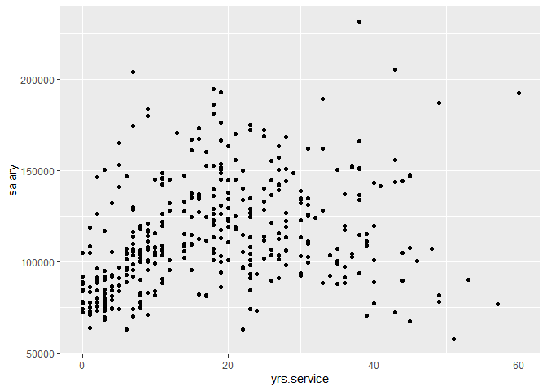

```r
ggplot(df) +
  geom_point(aes(x = yrs.service, y = salary))
```

## Q1.2

When aesthetics gets mapped to expressions, ggplot behaves as if a temporary variable was added to the data with with values equal to the result of the expression.

The result of `salary > 100000` is a logical variable which takes values of `TRUE` or `FALSE`.

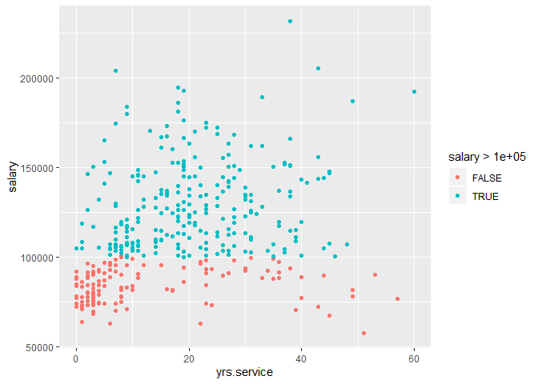

```r
ggplot(df) +
  geom_point(aes(x = yrs.service, y = salary, color=salary > 100000))
```

## Q1.3

For `color`, instead of using discrete colors, the continuous variable uses a scale that varies from a light to dark color.

For `size`, the sizes of the points vary continuously as a function of their size.

For `shape`, you get an error. (It doesn’t make sense.)

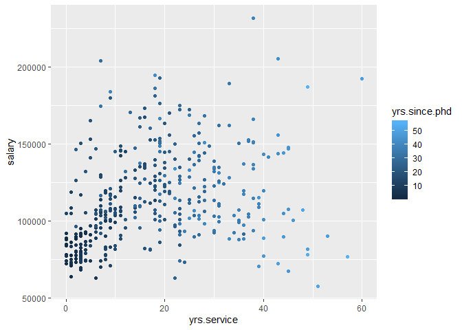

```r
ggplot(df) +
  geom_point(aes(x = yrs.service, y = salary, color=yrs.since.phd))
```

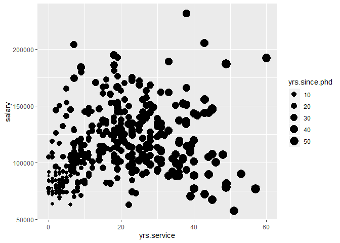

```r
ggplot(df) +
  geom_point(aes(x = yrs.service, y = salary, size=yrs.since.phd))
```

## Q1.4

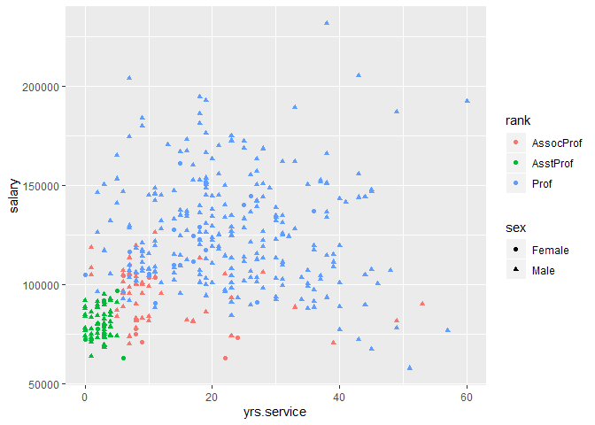

```r
ggplot(df) +
  geom_point(aes(x = yrs.service, y = salary, shape=sex, color=rank))
```

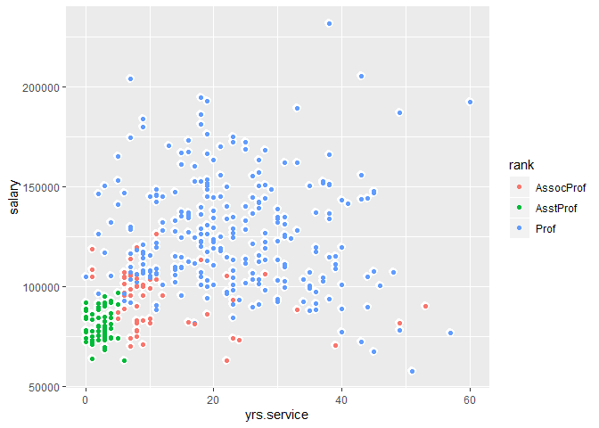

```r
ggplot(df) +
  geom_point(aes(x = yrs.service, y = salary), stroke = 2, color="white") +
  geom_point(aes(x = yrs.service, y = salary, color = rank))
```

## Q2.1

The difference between the two is the stat function they use.

The default stat of `geom_col()` is `stat_identity()`. (You need both x and y, y representing the bar heights.)

The default stat of `geom_bar()` is `stat_bin()`. (You only need the x. y variable will be the result of the preprocessing done on x variable.)

## Q2.2

[Here](http://letmegooglethat.com/?q=default+statistical+transformation+of+ggplot+geoms)

## Q2.3

As explained in Q1.2, since it is inside the `aes()` function, ggplot treats it as a new variable. (Categorical variable which only takes a single value)

This is the correct code:

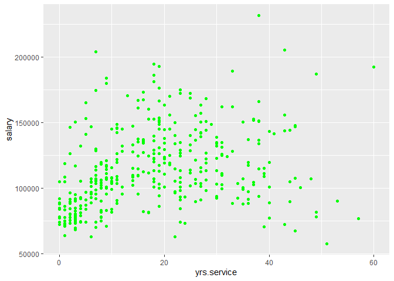

```r
ggplot(df) +
  geom_point(aes(x = yrs.service, y = salary), color = "green")
```

## Q2.5

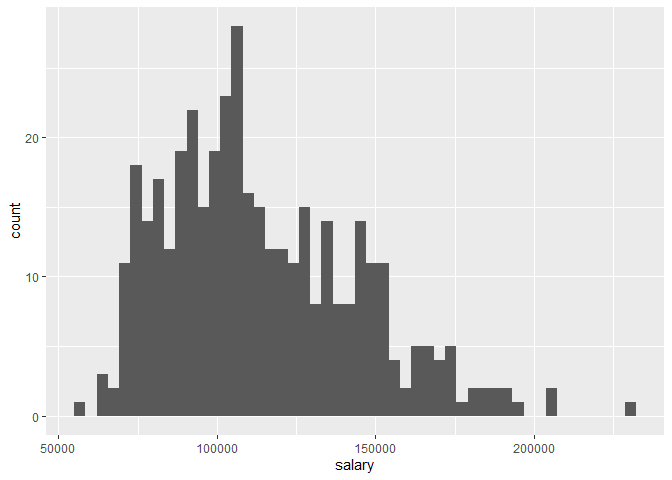

```r
ggplot(df) +
  geom_histogram(aes(x = salary), bins=50)
```

## Q2.6

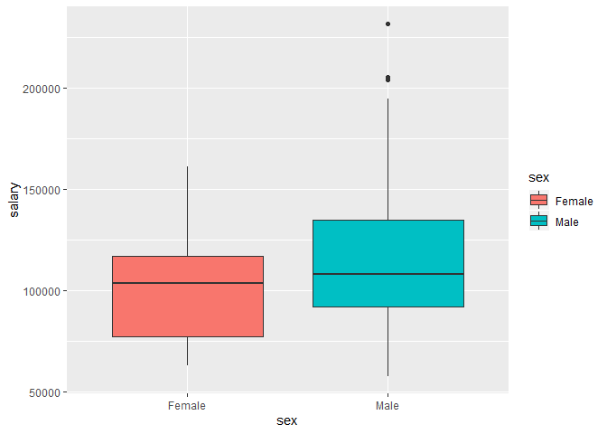

```r
ggplot(df) +
  geom_boxplot(aes(x=sex, y=salary, fill=sex))
```

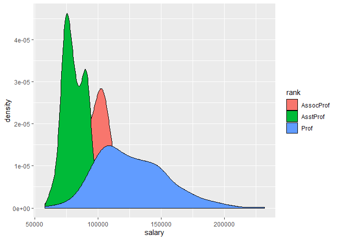

```r
ggplot(df) +
  geom_density(aes(x=salary, fill=rank))
```

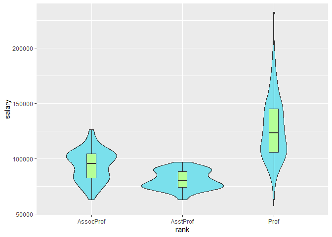

```r
ggplot(df) +
  geom_violin(aes(x=rank, y=salary), fill="#7AE0EC") +
  geom_boxplot(aes(x=rank, y=salary), fill="#B5FF97", width = 0.1)
```